# Homework Wk-2 Bayes

Shyni David

3/13/2019

```r
library(bayesm)
```

1. Copy the help file for runireg onto your text editor (>?runireg). Also copy code for runireg onto your text editor. The code, without comments, is listed by typing the “runireg” at the command prompt (>runireg)
2. Add comments to the file as a programmer would to indicate the steps being carried out. There should be a comment for each line of code stating what is being computed.

```r
my_runireg=function (y, X, betabar, A, nu, ssq)
{
    n = length(y)   # define the number of observation
    k = ncol(X) # define the number of independent variable
    RA = chol(A)    # cholesky decomposition of A=(RA)'(RA), RA is the upper
                  # triangular Cholesky root of A

    W = rbind(X, RA)    # W=(x,RA)'
    z = c(y, as.vector(RA %*% betabar)) # x=(y,RA*betabar)'
    IR = backsolve(chol(crossprod(W)), diag(k)) # UL decomposition: W'W=R'R,
                                #so solve(W'W)=(IR)*t(IR)
    btilde = crossprod(t(IR)) %*% crossprod(W, z)   # compute inv(W'W)*W'z.

    res = z - W %*% btilde   # compute the residual.
    s = t(res) %*% res       # compute the SSE.
    sigmasq = (nu * ssq + s)/rchisq(1, nu + n)  # draw sigmasq from
#Inverted Chi-square

    beta = btilde + as.vector(sqrt(sigmasq)) * IR %*% rnorm(k)
# draw beta from multivariate normal

    list(beta = beta, sigmasq = sigmasq)    # list the output variables
}
```

```r
R=2000
set.seed(66)

n = 200
X = cbind(rep(1,n), runif(n))
beta = c(1,2)
sigsq = 0.25
y = X%*%beta + rnorm(n,sd=sqrt(sigsq))

out = runireg(Data=list(y=y,X=X), Mcmc=list(R=R))
```

[output not shown]

```r
cat("Summary of beta and Sigmasq draws", fill=TRUE)
```

```
## Summary of beta and Sigmasq draws
```

```r
summary(out$betadraw, tvalues=beta)
```

[output not shown]

```r
summary(out$sigmasqdraw, tvalues=sigsq)
```

```
## Summary of Posterior Marginal Distributions
## Moments
##   tvalues mean std dev  num se rel eff sam size
## 1    0.25 0.25   0.025 0.00058    0.93     1800
##
## Quantiles
##   tvalues 2.5%   5%  50%  95% 97.5%
## 1    0.25  0.2 0.21 0.24 0.29   0.3
##    based on 1800 valid draws (burn-in=200)
```

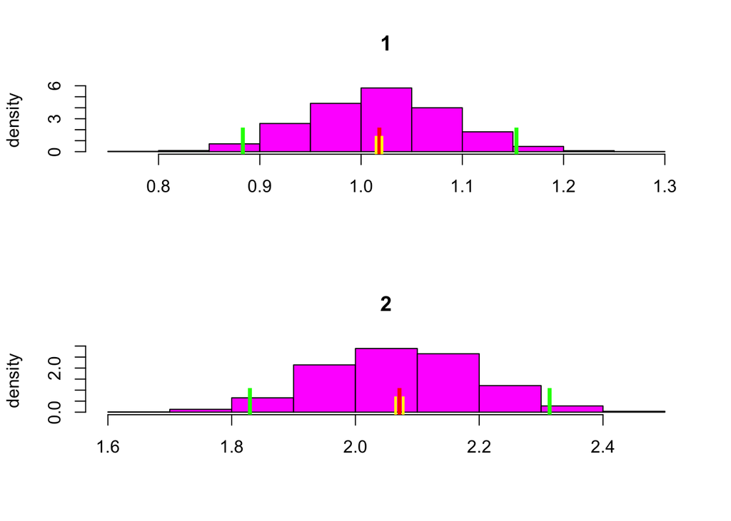

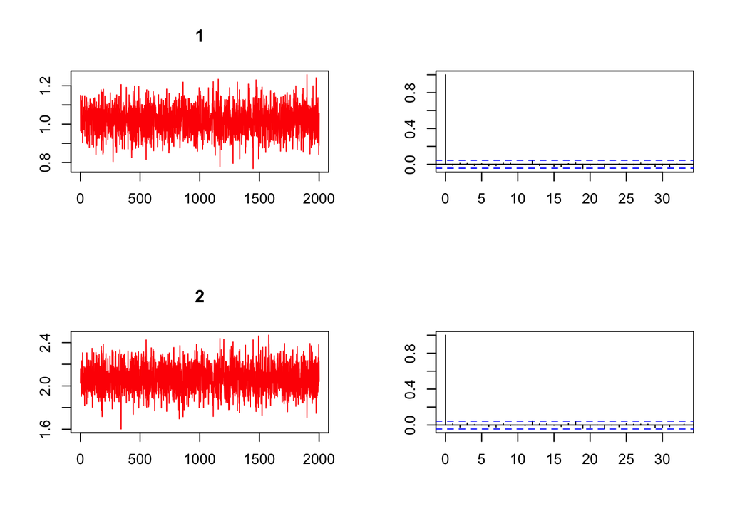

```r
## plotting examples
 plot(out$betadraw)
```

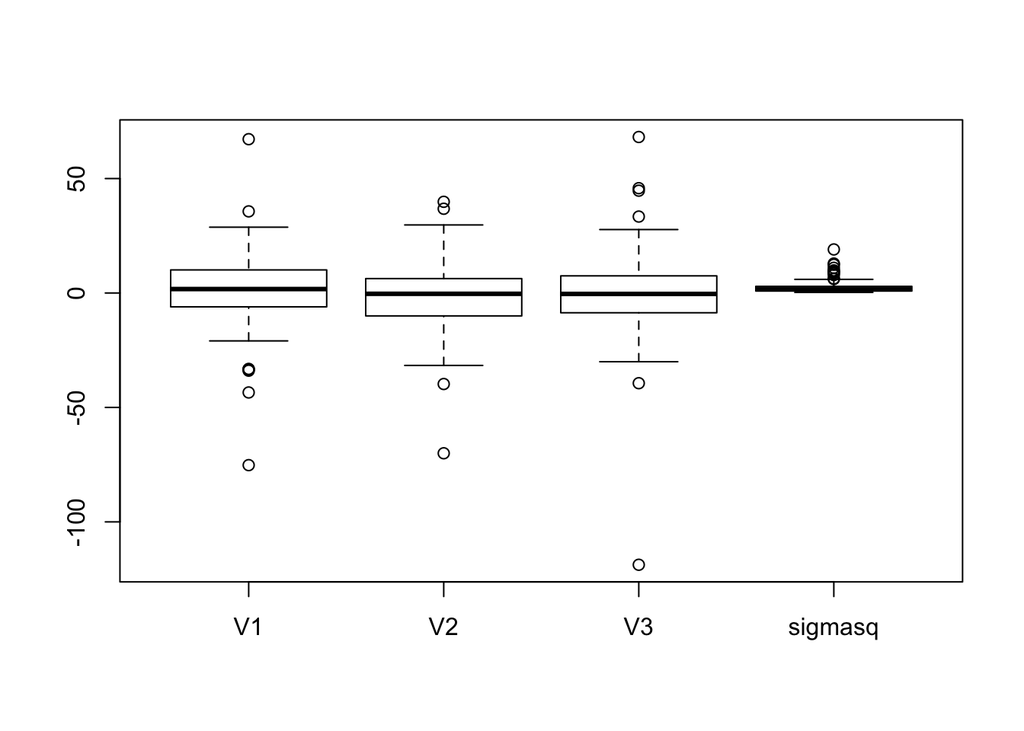

```r
library(MASS)
set.seed(123)
k = 3 ## Number of independent parameters (beta0,beta1,beta2)
nu =3 ## As given in the question
ssq = 1 ## As given in the question
R=100 ## Number of obsevations to be generated
A=diag(rep(0.01,k)) ## Diagonal matrix of dimension k=3. The diagonal elements are 0.1.
betabar=rep(0,k) ## Zero vector of dimensions equal to the number of independent parameters.



beta=array(double(R*k),dim=c(R,k)) ## defining an empty RXk array to be updated later.
sigmasq=array(double(R),dim=c(R)) ## defining an empty vector to be updated later

for (rep in 1:R) {
    # draw sigmasq from Inverted Chi-square with nu degrees of freedom.
    sigmasq[rep] = (nu * ssq)/rchisq(1, nu)  ## given in the formula

    ## Given that we know sigmasq, beta follows a multivariate normal distribution with mean = zero vector (beta bar) (dim = 3X1) and variance-cov matrix = sigmasq X Ainverse (dim=3X3).

    # draw beta from multivariate normal
    cov=sigmasq[rep]*solve(A) ## defining the var-covariance matrix. Solve used to calculate inverse of A.
    root=chol(cov)
    beta[rep,]=betabar+root%*%rnorm(k)  ## Sampling from a multivariate normal distribution with betabar as the mean vector and cov as the var-covariance matrix.

}

draws=cbind(beta,sigmasq)
boxplot(data.frame(draws))
```

5. Write your own R code to simulate a dataset of 100 observations from the following regression model by selecting a value of β and sigma2. The design matrix X contains an intercept and two independent variables.

```r
## for prior A = 0.01
n=100
X=cbind(rep(1,n),runif(n),runif(n)) ## Design matrix with intercept term as well.
## selecting a beta vector and the corresponding sigmasq from the ones generated in ques4)

beta_vector = beta[1,]
sigmasq_selected = draws[1,4]

y_vector = X%*%beta_vector + rnorm(n,sd=sqrt(sigmasq_selected)) ## vector of 100 observations
```

Get posterior draw

```r
betai=c(1,1,1)
sigsqi=3.0

Data<-list(y=y_vector,X=X)
Prior<-list(betabar=betabar,A=A,nu=nu,ssq=ssq)
Initial<-list(beta=betai,sigsq=sigsqi)
Mcmc<-list(R=2000,keep=10)

y=Data$y
X=Data$X

n = length(y)
k = ncol(X)

betabar=Prior$betabar
A=Prior$A
nu=Prior$nu
ssq=Prior$ssq

oldbeta=Initial$beta
oldsigsq=Initial$sigsq

R=Mcmc$R
keep=Mcmc$keep

betadraw=array(double(floor(R/keep)*k),dim=c(floor(R/keep),k))
sigsqdraw=array(double(floor(R/keep)),dim=c(floor(R/keep)))

for (rep in 1:R){

  #==============
  # draw sigmasq
  #==============
  sse=crossprod((y-X%*%oldbeta))
  oldsigsq = (nu * ssq + sse)/rchisq(1, nu + n)
  oldsigsq=oldsigsq[1,1] # redefine oldsiqsq as a scalar


  #=======================
  # draw beta
  #=======================
  avar=(1/oldsigsq)*(t(X)%*%X)+A
  avar=chol2inv(chol(avar))
  amean=(1/oldsigsq)*(t(X)%*%y)+A%*%betabar
  amean=avar%*%amean
  root=chol(avar)
  oldbeta=amean+root%*%rnorm(k)



  #==============
  # save draws
  #==============

  if(rep%%keep ==0){
    mkeep=rep/keep
    betadraw[mkeep,]=oldbeta
    sigsqdraw[mkeep]=oldsigsq
  }

  list(betadraw = betadraw, sigsqdraw = sigsqdraw)

} # end of rep-loop
```

time series plot

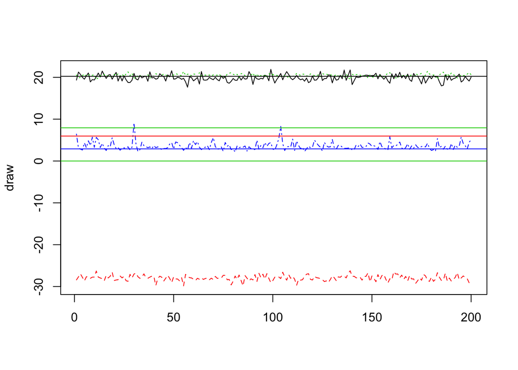

```r
draw=cbind(betadraw,sigsqdraw)
matplot(draw,type="l",col=c(1:4))
for (b in 1:3){
  abline(beta[b],0,col=b)
}
abline(0,0,col=3)
abline(sigmasq_selected,0,col=4)
```

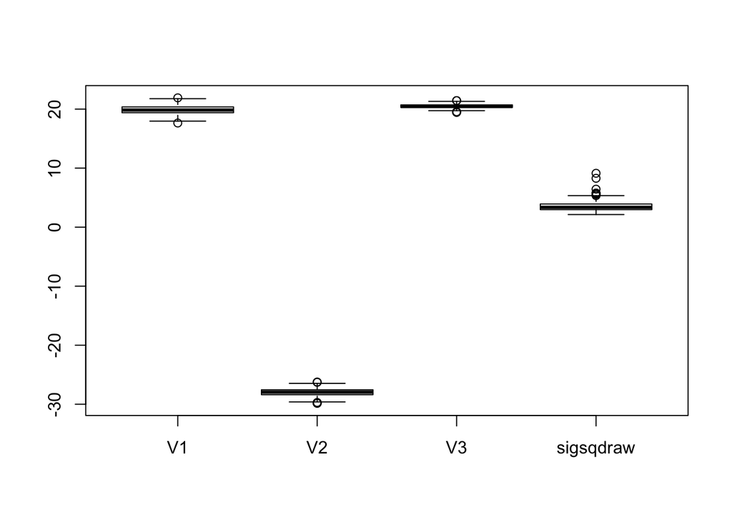

```r
# boxplot


boxplot(data.frame(draw))
```

```r
    # posterior mean and posterior std

     pmean=apply(draw,2,mean)
     pmean
```

```
##                                   sigsqdraw
##  19.881025 -27.954124  20.470218   3.577961
```

```r
     pstd=sqrt(apply(draw,2,var))
     pstd
```

```
##                               sigsqdraw
## 0.7628191 0.6682634 0.3499756 0.9536223
```